# OLIST01：期中專案資料彙整

中山大學管理學院 卓雍然

2021-04-06 19:30:29

### 【A】讀進資料

```r
pacman::p_load(dplyr, ggplot2, readr)
```

```r
# R = read_csv("data/olist_order_reviews_dataset.csv")
# L = read_csv("data/olist_marketing_qualified_leads_dataset.csv")
# Q = read_csv("data/olist_closed_deals_dataset.csv")
# I = read_csv("data/olist_order_items_dataset.csv")
# C = read_csv("data/olist_customers_dataset.csv")
# O = read_csv("data/olist_orders_dataset.csv")
# P = read_csv("data/olist_products_dataset.csv")
# S = read_csv("data/olist_sellers_dataset.csv")
# TPC = read_csv("data/product_category_name_translation.csv")
#
# attr(R, "spec") = NULL
# attr(L, "spec") = NULL
# attr(Q, "spec") = NULL
# attr(I, "spec") = NULL
# attr(C, "spec") = NULL
# attr(O, "spec") = NULL
# attr(P, "spec") = NULL
# attr(S, "spec") = NULL
# attr(TPC, "spec") = NULL
#
# save(R,L,Q,I,C,O,P,S,TPC, file="data/olist.rdata")
```

💡 讀完原始資料之後，先將資料壓縮起來，之後再從壓縮檔讀進會比較快、比較方便

```r
rm(list=ls(all=T))
load("data/olist.rdata")
```

### 【B】關聯式(Relational)資料與鍵值(Key)

##### § 確認鍵值欄位 Unique Key

Sellers: `S$seller_id`

```r
n_distinct(S$seller_id) == nrow(S)
```

```
[1] TRUE
```

Products: `P$product_id`

```r
n_distinct(P$product_id) == nrow(P)
```

```
[1] TRUE
```

##### § 多重鍵值 Multiple Key

Reviews: `R$review_id`

```r
n_distinct(R$review_id) == nrow(R)
```

```
[1] FALSE
```

Reviews: `R$review_id` & `R$order_id`

```r
nrow(unique(R[, 1:2])) == nrow(R)
```

```
[1] TRUE
```

一則評論最多可能談到三個訂單

```r
table(R$review_id) %>% table
```

```
.
    1     2     3
98371   777    25
```

##### § 外部鍵值 Foreign Key

Order Items: `I$order_id` & `I$order_item_id`

```r
nrow(unique(I[, 1:2])) == nrow(I)
```

```
[1] TRUE
```

### 【C】檢視資料

🗿 一筆訂單最多會有多少項目(`order_item_id`)呢？

```r
#同一筆訂單買了多少東西
count(I, order_id, sort=T)
```

```
# A tibble: 98,666 x 2
   order_id                             n
   <chr>                            <int>
 1 8272b63d03f5f79c56e9e4120aec44ef    21
 2 1b15974a0141d54e36626dca3fdc731a    20
 3 ab14fdcfbe524636d65ee38360e22ce8    20
 4 428a2f660dc84138d969ccd69a0ab6d5    15
 5 9ef13efd6949e4573a18964dd1bbe7f5    15
 6 73c8ab38f07dc94389065f7eba4f297a    14
 7 9bdc4d4c71aa1de4606060929dee888c    14
 8 37ee401157a3a0b28c9c6d0ed8c3b24b    13
 9 2c2a19b5703863c908512d135aa6accc    12
10 3a213fcdfe7d98be74ea0dc05a8b31ae    12
# ... with 98,656 more rows
```

🗿 一筆訂單最多會有多少個賣家(`seller_id`)呢？

```r
unique(I[, c(1,4)])$order_id %>% table %>% table
```

```
.
    1     2     3     4     5
97388  1219    54     3     2
```

```r
distinct(I[, c(1,4)]) %>% count(order_id) %>% count(n)
```

```
Storing counts in `nn`, as `n` already present in input
i Use `name = "new_name"` to pick a new name.
```

```
# A tibble: 5 x 2
      n    nn
* <int> <int>
1     1 97388
2     2  1219
3     3    54
4     4     3
5     5     2
```

🗿 一筆訂單最多會包含多少種產品(`product_id`)呢？

```r
unique(I[, c(1,3)])$order_id %>% table %>% table
```

```
.
    1     2     3     4     5     6     7     8
95430  2846   298    70     8    10     3     1
```

```r
#
```

### 【D】彙整資料、製作欄位

💡 做分析之前我們一定要先決定分析對象(Unit of Analysis)

假如我們要對所有的賣家做分析，我們就要依`selller_id`做彙總； 先從訂單項目(`I`)做起

```r
Z = I %>% group_by(seller_id) %>% summarise(
  ItemsSold = n(),
  Rev = sum(price),
  noProd = n_distinct(product_id),
  avgPrice = mean(price),
  maxPrice = max(price),
  minPrice = min(price),
  avgFreight = mean(freight_value),
  avgRevProd = Rev/noProd,
  avgItemsProd = ItemsSold/noProd
  )
summary(Z)
```

```
  seller_id           ItemsSold           Rev             noProd
 Length:3095        Min.   :   1.0   Min.   :     4   Min.   :  1.0
 Class :character   1st Qu.:   2.0   1st Qu.:   209   1st Qu.:  2.0
 Mode  :character   Median :   8.0   Median :   821   Median :  4.0
                    Mean   :  36.4   Mean   :  4391   Mean   : 11.1
                    3rd Qu.:  24.0   3rd Qu.:  3281   3rd Qu.: 10.0
                    Max.   :2033.0   Max.   :229473   Max.   :399.0
    avgPrice         maxPrice         minPrice        avgFreight
 Min.   :   3.5   Min.   :   3.5   Min.   :   0.8   Min.   :  1.2
 1st Qu.:  52.2   1st Qu.:  81.0   1st Qu.:  21.6   1st Qu.: 14.7
 Median :  95.5   Median : 169.9   Median :  44.8   Median : 18.2
 Mean   : 176.3   Mean   : 335.4   Mean   : 110.4   Mean   : 23.4
 3rd Qu.: 174.0   3rd Qu.: 349.9   3rd Qu.:  99.0   3rd Qu.: 24.4
 Max.   :6729.0   Max.   :6735.0   Max.   :6729.0   Max.   :308.3
   avgRevProd       avgItemsProd
 Min.   :    3.5   Min.   :  1.00
 1st Qu.:   89.0   1st Qu.:  1.00
 Median :  179.8   Median :  1.67
 Mean   :  417.5   Mean   :  2.67
 3rd Qu.:  397.7   3rd Qu.:  2.73
 Max.   :16983.5   Max.   :128.33
```

```r
str(Z)
```

```
tibble [3,095 x 10] (S3: tbl_df/tbl/data.frame)
 $ seller_id   : chr [1:3095] "0015a82c2db000af6aaaf3ae2ecb0532" "001cca7ae9ae17fb1caed9dfb1094831" "001e6ad469a905060d959994f1b41e4f" "002100f778ceb8431b7a1020ff7ab48f" ...
 $ ItemsSold   : int [1:3095] 3 239 1 55 1 170 26 1 1 172 ...
 $ Rev         : num [1:3095] 2685 25080 250 1234 120 ...
 $ noProd      : int [1:3095] 1 11 1 24 1 88 9 1 1 23 ...
 $ avgPrice    : num [1:3095] 895 104.9 250 22.4 120 ...
 $ maxPrice    : num [1:3095] 895 199 250 130 120 ...
 $ minPrice    : num [1:3095] 895 69.9 250 9.9 120 47.9 13.5 98 86 48 ...
 $ avgFreight  : num [1:3095] 21 37 17.9 14.4 19.4 ...
 $ avgRevProd  : num [1:3095] 2685 2280 250 51.4 120 ...
 $ avgItemsProd: num [1:3095] 3 21.73 1 2.29 1 ...
```

計算每一個賣家的評等時要考慮：

- 每一則評論可能有多於一個訂單而
- 每一筆訂單可能包含多一個賣家

這兩個問題。

```r
X = unique(I[,c(1,4)]) %>% left_join(R[,2:3]) %>%
  group_by(seller_id) %>% summarise(
    noReview = n(),
    avgScore = mean(review_score),
    minScore = min(review_score),
    maxScore = max(review_score))
summary(X)
```

```
  seller_id            noReview         avgScore       minScore
 Length:3095        Min.   :   1.0   Min.   :1.00   Min.   :1.00
 Class :character   1st Qu.:   2.0   1st Qu.:3.75   1st Qu.:1.00
 Mode  :character   Median :   7.0   Median :4.17   Median :1.00
                    Mean   :  32.5   Mean   :3.98   Mean   :2.25
                    3rd Qu.:  22.0   3rd Qu.:4.60   3rd Qu.:4.00
                    Max.   :1860.0   Max.   :5.00   Max.   :5.00
    maxScore
 Min.   :1.00
 1st Qu.:5.00
 Median :5.00
 Mean   :4.69
 3rd Qu.:5.00
 Max.   :5.00
```

最後併入賣家的基本資料

```r
Z = Z %>% left_join(X) %>% left_join(S)
is.na(Z) %>% colSums
```

```
             seller_id              ItemsSold                    Rev
                     0                      0                      0
                noProd               avgPrice               maxPrice
                     0                      0                      0
              minPrice             avgFreight             avgRevProd
                     0                      0                      0
          avgItemsProd               noReview               avgScore
                     0                      0                      0
              minScore               maxScore seller_zip_code_prefix
                     0                      0                      0
           seller_city           seller_state
                     0                      0
```

做一個簡單的分析： 賣家的平均評等最高的20個省份是 …

```r
tapply(Z$avgScore, Z$seller_state, mean) %>% sort %>% tail(20)
```

```
    SE     RO     BA     SP     RJ     MA     PR     DF     MG     RS     SC
3.8500 3.8542 3.9316 3.9541 3.9657 3.9720 4.0155 4.0319 4.0336 4.0501 4.0725
    PI     GO     PE     ES     MT     MS     PB     RN     PA
4.0833 4.1011 4.1091 4.1959 4.2231 4.2510 4.2812 4.4757 4.5000
```

### 【E】併入其它資料

`Funnel`資料集裡面有更多賣家欄位，但是它的資料筆數不多

```r
Z1 = left_join(Q, L) %>% inner_join(Z)
dim(Z1)
```

```
[1] 380  33
```

依賣家的行為做彙總

```r
behavior = group_by(Z1, lead_behaviour_profile) %>% summarise(
  noSellers = n(),
  totalRev = sum(Rev),
  avgRev = mean(Rev),
  avgReview = mean(noReview),
  avgScore = mean(avgScore)
  ) %>% arrange( desc(avgScore) )
behavior
```

```
# A tibble: 7 x 6
  lead_behaviour_profile noSellers totalRev avgRev avgReview avgScore
  <chr>                      <int>    <dbl>  <dbl>     <dbl>    <dbl>
1 cat, wolf                      1      59     59       1        5
2 wolf                          43   21378.   497.      4.60     4.39
3 <NA>                          91  231802.  2547.     17.0      4.33
4 eagle                         50   90725.  1814.     13.5      4.28
5 cat                          184  282479.  1535.      9.64     4.25
6 shark                         10   49512.  4951.     32.3      4.23
7 eagle, cat                     1     896    896       3        3.33
```

依產業別做彙總

```r
segment = group_by(Z1, business_segment) %>% summarise(
  noSellers = n(),
  totalRev = sum(Rev),
  avgItemsSold = mean(ItemsSold),
  avgPrice = totalRev/avgItemsSold,
  avgRev = mean(Rev),
  avgReview = mean(noReview),
  avgScore = mean(avgScore)
  ) %>% arrange( desc(totalRev) )
segment
```

```
# A tibble: 29 x 8
   business_segment    noSellers totalRev avgItemsSold avgPrice avgRev avgReview
   <chr>                   <int>    <dbl>        <dbl>    <dbl>  <dbl>     <dbl>
 1 watches                     3  117279.       198        592. 39093.    193.
 2 health_beauty              45   90836.        18.2     4979.  2019.     15.7
 3 household_utilities        44   51569.        12.8     4045.  1172.     11.4
 4 audio_video_electr~        31   50265.         8.87    5666.  1621.      8.03
 5 small_appliances            7   47675.         9.86    4837.  6811.      9.71
 6 home_decor                 44   44102.        10.3     4293.  1002.      8.23
 7 pet                        17   40499.        16.8     2407.  2382.     14.6
 8 construction_tools~        32   34539.         9.94    3476.  1079.      8.5
 9 car_accessories            30   30175.         5.47    5520.  1006.      4.93
10 home_appliances             5   26241.        28.2      931.  5248.     27
# ... with 19 more rows, and 1 more variable: avgScore <dbl>
```

儲存資料物件

```r
save(Z, Z1, segment, file="data/Z.rdata")
```

🧙 問題討論：  
請大家參考一下上學期的[期中競賽影片集](https://www.youtube.com/playlist?list=PLvOqBoPSLQJczkdp-tJUIb6c8WvKvDDSy)，  
假如老闆給妳這一份資料，讓你透過資料分析提出一些對公司營運有幫助的建議，  
請妳用我們已經學過的資料分析技巧先做一些資料探索，比方說：  
■ 找出營收貢獻最大的賣家和產品

```r
#營收貢獻最大的賣家
#Z$seller_id
Z[order(-Z$Rev),c(1:3)] #row,col
```

```
# A tibble: 3,095 x 3
   seller_id                        ItemsSold     Rev
   <chr>                                <int>   <dbl>
 1 4869f7a5dfa277a7dca6462dcf3b52b2      1156 229473.
 2 53243585a1d6dc2643021fd1853d8905       410 222776.
 3 4a3ca9315b744ce9f8e9374361493884      1987 200473.
 4 fa1c13f2614d7b5c4749cbc52fecda94       586 194042.
 5 7c67e1448b00f6e969d365cea6b010ab      1364 187924.
 6 7e93a43ef30c4f03f38b393420bc753a       340 176432.
 7 da8622b14eb17ae2831f4ac5b9dab84a      1551 160237.
 8 7a67c85e85bb2ce8582c35f2203ad736      1171 141746.
 9 1025f0e2d44d7041d6cf58b6550e0bfa      1428 138969.
10 955fee9216a65b617aa5c0531780ce60      1499 135172.
# ... with 3,085 more rows
```

```r
#營收貢獻最大的產品
product = group_by(I, product_id) %>%
  summarise(
  p_sumprice=sum(price)
) %>% arrange( desc(p_sumprice) )
product
```

```
# A tibble: 32,951 x 2
   product_id                       p_sumprice
   <chr>                                 <dbl>
 1 bb50f2e236e5eea0100680137654686c     63885
 2 6cdd53843498f92890544667809f1595     54730.
 3 d6160fb7873f184099d9bc95e30376af     48899.
 4 d1c427060a0f73f6b889a5c7c61f2ac4     47215.
 5 99a4788cb24856965c36a24e339b6058     43026.
 6 3dd2a17168ec895c781a9191c1e95ad7     41083.
 7 25c38557cf793876c5abdd5931f922db     38907.
 8 5f504b3a1c75b73d6151be81eb05bdc9     37734.
 9 53b36df67ebb7c41585e8d54d6772e08     37683.
10 aca2eb7d00ea1a7b8ebd4e68314663af     37609.
# ... with 32,941 more rows
```

■ 各州或者各品類(`segment`)的營收貢獻有什麼長期趨勢嗎？

```r
group_by(P, product_category_name) %>%
  summarise(
  p_category= n()
) %>% arrange(desc(p_category)) %>% head(5)
```

```
# A tibble: 5 x 2
  product_category_name p_category
  <chr>                      <int>
1 cama_mesa_banho             3029
2 esporte_lazer               2867
3 moveis_decoracao            2657
4 beleza_saude                2444
5 utilidades_domesticas       2335
```

```r
C1 = left_join(O, C, by = "customer_id")
head(C1)
```

```
# A tibble: 6 x 12
  order_id    customer_id   order_status order_purchase_tim~ order_approved_at
  <chr>       <chr>         <chr>        <dttm>              <dttm>
1 e481f51cbd~ 9ef432eb6251~ delivered    2017-10-02 10:56:33 2017-10-02 11:07:15
2 53cdb2fc8b~ b0830fb4747a~ delivered    2018-07-24 20:41:37 2018-07-26 03:24:27
3 47770eb910~ 41ce2a54c0b0~ delivered    2018-08-08 08:38:49 2018-08-08 08:55:23
4 949d5b44db~ f88197465ea7~ delivered    2017-11-18 19:28:06 2017-11-18 19:45:59
5 ad21c59c08~ 8ab97904e6da~ delivered    2018-02-13 21:18:39 2018-02-13 22:20:29
6 a4591c265e~ 503740e9ca75~ delivered    2017-07-09 21:57:05 2017-07-09 22:10:13
# ... with 7 more variables: order_delivered_carrier_date <dttm>,
#   order_delivered_customer_date <dttm>, order_estimated_delivery_date <dttm>,
#   customer_unique_id <chr>, customer_zip_code_prefix <chr>,
#   customer_city <chr>, customer_state <chr>
```

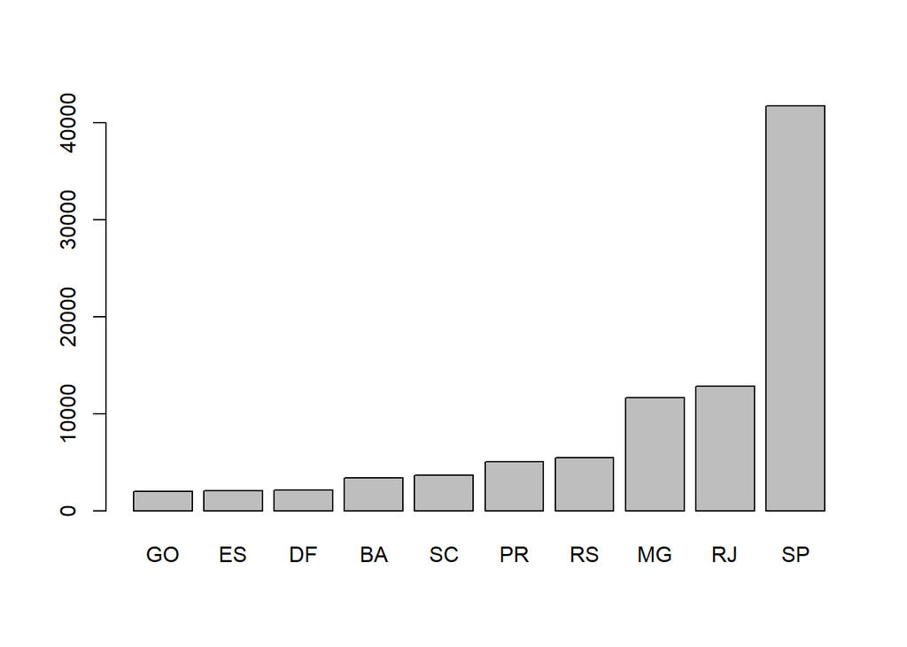

```r
p <- C1 %>% group_by(C1$customer_state) %>%
  summarise(
    count = n()
    #order_purchase_timestamp = as.POSIXct(C1$order_purchase_timestamp, format="%m/%d/%y %H:%M:%S")
  )

table(C1$customer_state) %>% sort() %>% tail(10) %>% barplot(beside=T)
```

■ 顧客下訂單的時間(`order_purchase_timestamp`)有什麼特別的樣態嗎？

```r
#以月分來看顧客下單時間
#可以發現2017年1月開始訂單增加，並在11月時達到高峰並穩定成長
#O$order_purchase_timestamp = as.Date(O$order_purchase_timestamp)
str(O)
```

```
tibble [99,441 x 8] (S3: tbl_df/tbl/data.frame)
 $ order_id                     : chr [1:99441] "e481f51cbdc54678b7cc49136f2d6af7" "53cdb2fc8bc7dce0b6741e2150273451" "47770eb9100c2d0c44946d9cf07ec65d" "949d5b44dbf5de918fe9c16f97b45f8a" ...
 $ customer_id                  : chr [1:99441] "9ef432eb6251297304e76186b10a928d" "b0830fb4747a6c6d20dea0b8c802d7ef" "41ce2a54c0b03bf3443c3d931a367089" "f88197465ea7920adcdbec7375364d82" ...
 $ order_status                 : chr [1:99441] "delivered" "delivered" "delivered" "delivered" ...
 $ order_purchase_timestamp     : POSIXct[1:99441], format: "2017-10-02 10:56:33" "2018-07-24 20:41:37" ...
 $ order_approved_at            : POSIXct[1:99441], format: "2017-10-02 11:07:15" "2018-07-26 03:24:27" ...
 $ order_delivered_carrier_date : POSIXct[1:99441], format: "2017-10-04 19:55:00" "2018-07-26 14:31:00" ...
 $ order_delivered_customer_date: POSIXct[1:99441], format: "2017-10-10 21:25:13" "2018-08-07 15:27:45" ...
 $ order_estimated_delivery_date: POSIXct[1:99441], format: "2017-10-18" "2018-08-13" ...
```

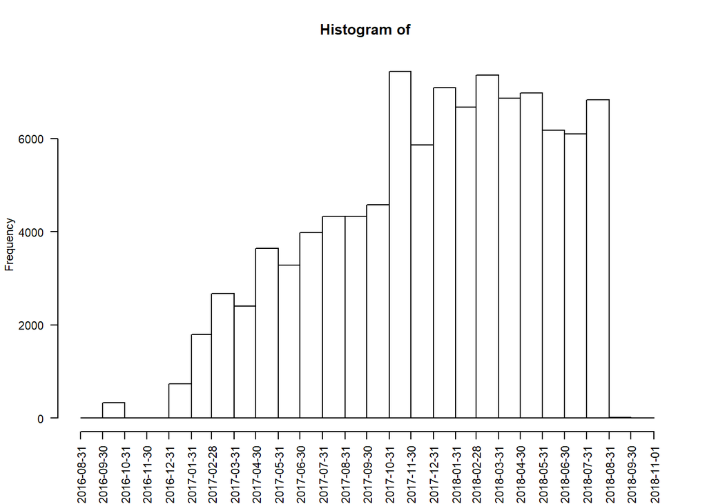

```r
p <- O %>% group_by(O$order_purchase_timestamp) %>%
  summarise(
    count = n()
  )
#plot(p)

ts = as.POSIXct(O$order_purchase_timestamp, format="%m/%d/%y %H:%M:%S")
par(cex=0.7)
hist(ts,"month",las=2,freq=T,xlab="")
```